# Studiensimulation: Implantatverlust

Überlebenszeitanalyse – dieselbe Frage, zwei Studiendesigns: RCT und Routinedaten

[figure not shown]

## Worum es geht

Wir betrachten **Vitamin D und die Osseointegration von Zahnimplantaten** – und zwar bewusst mit **zwei verschiedenen Studiendesigns**, weil sich daran die wichtigsten Konzepte am besten zeigen lassen:

- **Teil A – die randomisierte Studie (RCT):** Die *Gabe* von Vitamin D vor der Implantation wird per Zufall zugeteilt. Kernbotschaft: Durch die Randomisierung ist **nichts ein Confounder** – wir müssen für nichts adjustieren.
- **Teil B – Routinedaten (Beobachtung):** Wir haben *keine* Studie, sondern nur Praxisdaten, in denen der gemessene **Vitamin-D-Spiegel** und das Implantatüberleben stehen. Jetzt wird **Confounding** real – und wir müssen es mit DAG und gezielter Confounder-Adjustierung behandeln.

Beide Teile nutzen dieselben Methoden (Kaplan-Meier, Cox-Regression), aber die **Interpretation** unterscheidet sich fundamental. Der Code ist eingeklappt – über „Code anzeigen” lässt sich jeder Schritt öffnen.

**Code anzeigen**

```r
library(dplyr)
library(forcats)
library(survival)
library(survminer)
library(gtsummary)
library(flextable)
library(ggdag)
library(dagitty)
library(lmtest)
library(here)
```

# Teil A – Die randomisierte Studie (RCT)

Die Vitamin-D-Gabe (`vit_d_gabe`) wurde **randomisiert** zugeteilt. Der Datensatz ist bereits aufbereitet: Aus den Datumsangaben wurden schon der Ereignisstatus `lost` (1 = Implantat verloren, 0 = zensiert) und die Beobachtungszeit `months_passed` (Monate bis Verlust bzw. letztem Kontakt) berechnet.

**Code anzeigen**

```r
rct <- readRDS(here("Daten", "Beispieldaten_RCT.rds")) |>
  mutate(
    female       = factor(female,       c(0, 1), c("männlich", "weiblich")),
    smoke        = factor(smoke,        c(0, 1), c("Nichtraucher", "Raucher")),
    vit_d_gabe   = factor(vit_d_gabe,   c(0, 1), c("keine Gabe", "Vitamin-D-Gabe")),
    vit_d_mangel = factor(vit_d_mangel, c(0, 1), c("kein Mangel", "Mangel"))
  )

glimpse(rct)
```

```
Rows: 2,045
Columns: 16
$ patient_id         <dbl> 1, 1, 2, 2, 3, 3, 3, 3, 4, 5, 5, 5, 5, 5, 5, 6, 6, …
$ implant_id         <dbl> 1, 2, 3, 4, 5, 6, 7, 8, 9, 10, 11, 12, 13, 14, 15, …
$ geb                <dttm> 1950-03-28, 1943-02-28, 1958-06-24, 1957-10-04, 19…
$ female             <fct> weiblich, weiblich, männlich, männlich, weiblich, w…
$ Implantationsdatum <dttm> 2012-03-28, 2005-02-28, 2012-06-24, 2011-10-05, 20…
$ alter              <dbl> 62, 62, 54, 54, 54, 54, 54, 54, 68, 80, 80, 80, 80,…
$ last_visit         <dttm> 2014-03-29, 2005-08-30, 2015-06-25, 2021-10-05, 20…
$ smoke              <fct> Nichtraucher, Nichtraucher, Nichtraucher, Nichtrauc…
$ vit_d_gabe         <fct> Vitamin-D-Gabe, Vitamin-D-Gabe, keine Gabe, keine G…
$ vit_d_spiegel      <dbl> 36.1, 36.1, 29.3, 29.3, 18.0, 18.0, 18.0, 18.0, 37.…
$ vit_d_mangel       <fct> kein Mangel, kein Mangel, kein Mangel, kein Mangel,…
$ position           <dbl> 27, 46, 17, 17, 23, 34, 26, 16, 14, 26, 25, 37, 22,…
$ anzahl_impl        <dbl> 2, 2, 2, 2, 4, 4, 4, 4, 1, 6, 6, 6, 6, 6, 6, 2, 2, …
$ lost_date          <dttm> NA, 2005-08-30, 2015-06-25, NA, NA, 2010-09-17, NA…
$ lost               <dbl> 0, 1, 1, 0, 0, 1, 0, 0, 0, 1, 1, 0, 0, 0, 1, 0, 0, …
$ months_passed      <dbl> 24, 6, 36, 120, 120, 60, 120, 120, 120, 96, 120, 12…
```

## Tabelle 1: Sind die Gruppen vergleichbar?

Der klassische erste Schritt einer RCT-Auswertung: zeigen, dass die Randomisierung die Gruppen **balanciert** hat. Wir stellen die Merkmale den beiden Behandlungsgruppen gegenüber.

**Code anzeigen**

```r
rct |>
  distinct(patient_id, .keep_all = TRUE) |>
  select(vit_d_gabe, alter, female, smoke, vit_d_spiegel, vit_d_mangel) |>
  tbl_summary(
    by = vit_d_gabe,
    label = list(alter ~ "Alter (Jahre)", female ~ "Geschlecht",
                 smoke ~ "Rauchen", vit_d_spiegel ~ "Vitamin-D-Spiegel (ng/ml)",
                 vit_d_mangel ~ "Vitamin-D-Mangel")
  ) |>
  modify_header(label ~ "**Charakteristik**") |>
  modify_spanning_header(all_stat_cols() ~ "**Vitamin-D-Gabe (randomisiert)**") |>
  as_flex_table()
```

| Charakteristik | Vitamin-D-Gabe (randomisiert) keine Gabe N = 4121 | Vitamin-D-Gabe (randomisiert) Vitamin-D-Gabe N = 3881 |
| --- | --- | --- |
| Alter (Jahre) | 63 (56, 69) | 61 (54, 67) |
| Geschlecht |  |  |
| männlich | 197 (48%) | 197 (51%) |
| weiblich | 215 (52%) | 191 (49%) |
| Rauchen |  |  |
| Nichtraucher | 289 (70%) | 280 (72%) |
| Raucher | 123 (30%) | 108 (28%) |
| Vitamin-D-Spiegel (ng/ml) | 25 (18, 31) | 24 (18, 30) |
| Vitamin-D-Mangel |  |  |
| kein Mangel | 294 (71%) | 256 (66%) |
| Mangel | 118 (29%) | 132 (34%) |

1Median (Q1, Q3); n (%)

Alter, Geschlecht, Rauchen und Vitamin-D-Status sind zwischen den Gruppen praktisch gleich verteilt. Genau das leistet die Randomisierung.

**NoteWarum hier keine p-Werte in Tabelle 1?**

Ein Signifikanztest auf „Gruppenunterschied” ist in einer RCT unsinnig: Wir *wissen*, dass zufällig zugeteilt wurde. Kleine Unterschiede sind per Definition Zufall. Die Tabelle dient der **Beschreibung**, nicht dem Testen.

## Kaplan-Meier und Log-Rank

Das `Surv()`-Objekt bündelt Beobachtungszeit und Ereignis (`+` = zensiert):

**Code anzeigen**

```r
head(Surv(rct$months_passed, rct$lost), 15)
```

```
 [1]  24+   6   36  120+ 120+  60  120+ 120+ 120+  96  120  120+ 120+ 120+   6
```

**Code anzeigen**

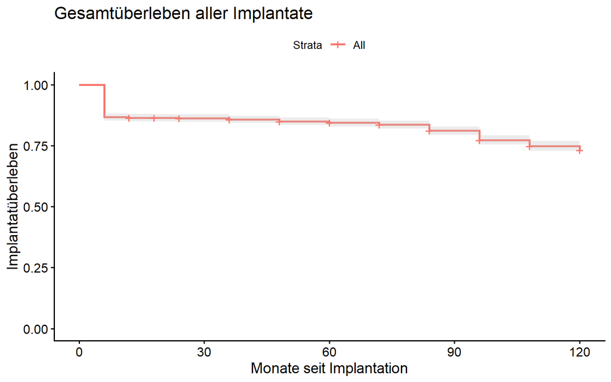

```r
ggsurvplot(
  survfit(Surv(months_passed, lost) ~ 1, data = rct), data = rct, conf.int = TRUE,
  xlab = "Monate seit Implantation", ylab = "Implantatüberleben",
  title = "Gesamtüberleben aller Implantate"
)
```

Typisches Muster: früher Abfall (Osseointegration) und eine zweite Verlustwelle nach ~7–8 Jahren. Nun nach Vitamin-D-Gabe:

**Code anzeigen**

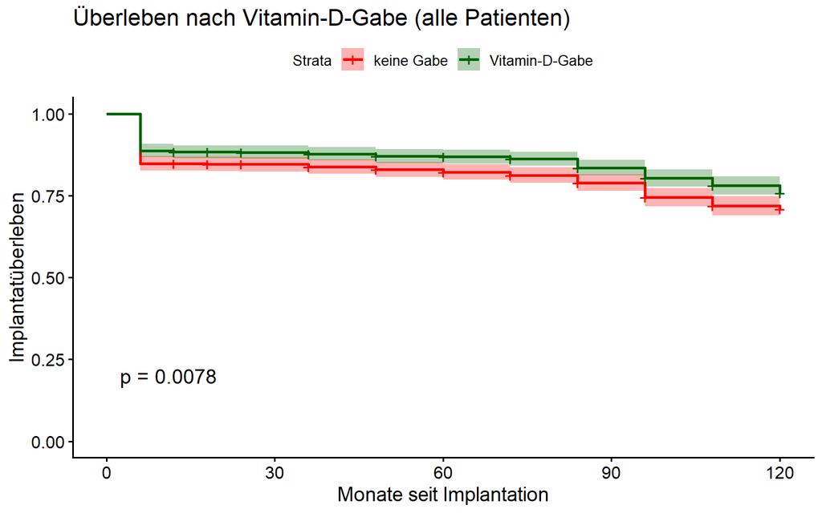

```r
ggsurvplot(
  survfit(Surv(months_passed, lost) ~ vit_d_gabe, data = rct), data = rct,
  pval = TRUE, conf.int = TRUE, palette = c("red", "darkgreen"),
  legend.labs = c("keine Gabe", "Vitamin-D-Gabe"),
  xlab = "Monate seit Implantation", ylab = "Implantatüberleben",
  title = "Überleben nach Vitamin-D-Gabe (alle Patienten)"
)
```

Über **alle** Patienten ist der Unterschied nur mäßig – ein Hinweis darauf, dass die Gabe vielleicht nicht allen gleich nützt (dazu Abschnitt *Effektmodifikation*).

## Cox-Regression: im RCT braucht es keine Confounder-Adjustierung

Die **Cox-Regression** liefert **Hazard Ratios (HR)** (< 1 = Schutz, > 1 = Risiko). Der entscheidende Punkt im RCT: Weil die Gabe randomisiert wurde, ist der **rohe (unadjustierte) Schätzer bereits unverzerrt**. Wir müssen für Alter, Geschlecht, Rauchen **nicht** adjustieren, um Bias zu vermeiden – die Balance-Tabelle oben ist der Beleg.

**Code anzeigen**

```r
coxph(Surv(months_passed, lost) ~ vit_d_gabe, data = rct) |>
  summary()
```

```
Call:
coxph(formula = Surv(months_passed, lost) ~ vit_d_gabe, data = rct)

  n= 2045, number of events= 482

                             coef exp(coef) se(coef)     z Pr(>|z|)
vit_d_gabeVitamin-D-Gabe -0.24646   0.78156  0.09197 -2.68  0.00737 **
---
Signif. codes:  0 '***' 0.001 '**' 0.01 '*' 0.05 '.' 0.1 ' ' 1

                         exp(coef) exp(-coef) lower .95 upper .95
vit_d_gabeVitamin-D-Gabe    0.7816      1.279    0.6526    0.9359

Concordance= 0.535  (se = 0.012 )
Likelihood ratio test= 7.24  on 1 df,   p=0.007
Wald test            = 7.18  on 1 df,   p=0.007
Score (logrank) test = 7.22  on 1 df,   p=0.007
```

### Clustering: das Frailty-Modell

Eine Adjustierung brauchen wir aus einem **anderen** Grund: Ein Patient hat oft **mehrere Implantate** (im Mittel ~2,5), die **nicht unabhängig** sind. Das hat nichts mit Confounding zu tun, sondern mit korrelierten Beobachtungen. Das **Frailty-Modell** (`frailty(patient_id)`) berücksichtigt das und liefert einen Test für das Clustering.

**Code anzeigen**

```r
cox_frailty <- coxph(
  Surv(months_passed, lost) ~ vit_d_gabe + frailty(patient_id), data = rct
)
summary(cox_frailty)
```

```
Call:
coxph(formula = Surv(months_passed, lost) ~ vit_d_gabe + frailty(patient_id),
    data = rct)

  n= 2045, number of events= 482

                         coef    se(coef) se2     Chisq DF  p
vit_d_gabeVitamin-D-Gabe -0.2998 0.1109   0.09328   7.3   1 0.0069
frailty(patient_id)                               258.0 205 0.0071

                         exp(coef) exp(-coef) lower .95 upper .95
vit_d_gabeVitamin-D-Gabe     0.741       1.35    0.5962    0.9209

Iterations: 7 outer, 29 Newton-Raphson
     Variance of random effect= 0.5885867   I-likelihood = -3535.5
Degrees of freedom for terms=   0.7 205.0
Concordance= 0.871  (se = 0.007 )
Likelihood ratio test= 418.7  on 205.7 df,   p=<2e-16
```

**Code anzeigen**

```r
lrtest(coxph(Surv(months_passed, lost) ~ vit_d_gabe, data = rct), cox_frailty)
```

```
Likelihood ratio test

Model 1: Surv(months_passed, lost) ~ vit_d_gabe
Model 2: Surv(months_passed, lost) ~ vit_d_gabe + frailty(patient_id)
    #Df  LogLik    Df  Chisq Pr(>Chisq)
1   1.0 -3550.3
2 205.7 -3344.6 204.7 411.44  5.854e-16 ***
---
Signif. codes:  0 '***' 0.001 '**' 0.01 '*' 0.05 '.' 0.1 ' ' 1
```

## Effektmodifikation: wirkt die Gabe nur bei Mangel?

Wir vermuten (biologisch plausibel): Eine Substitution kann nur helfen, wenn überhaupt ein **Mangel** besteht. Das ist eine **präspezifizierte** Hypothese – nicht nachträglich zusammengesucht. Zwei Dinge müssen für eine Effektmodifikation zusammenkommen: **biologische Plausibilität** *und* ein **signifikanter Interaktionsterm**.

**Code anzeigen**

```r
cox_int <- coxph(
  Surv(months_passed, lost) ~ vit_d_gabe * vit_d_mangel + frailty(patient_id),
  data = rct
)
summary(cox_int)$coefficients
```

```
                                                    coef  se(coef)       se2
vit_d_gabeVitamin-D-Gabe                    -0.001293109 0.1314180 0.1100603
vit_d_mangelMangel                           0.380182271 0.1615006 0.1321206
frailty(patient_id)                                   NA        NA        NA
vit_d_gabeVitamin-D-Gabe:vit_d_mangelMangel -0.995856413 0.2454420 0.2088862
                                                   Chisq       DF            p
vit_d_gabeVitamin-D-Gabe                    9.681886e-05   1.0000 9.921492e-01
vit_d_mangelMangel                          5.541606e+00   1.0000 1.856953e-02
frailty(patient_id)                         2.523029e+02 200.6091 7.759471e-03
vit_d_gabeVitamin-D-Gabe:vit_d_mangelMangel 1.646250e+01   1.0000 4.962188e-05
```

Der Interaktionsterm `vit_d_gabe:vit_d_mangel` ist signifikant – beide Bedingungen sind erfüllt. Die getrennten Kurven veranschaulichen es:

**Code anzeigen**

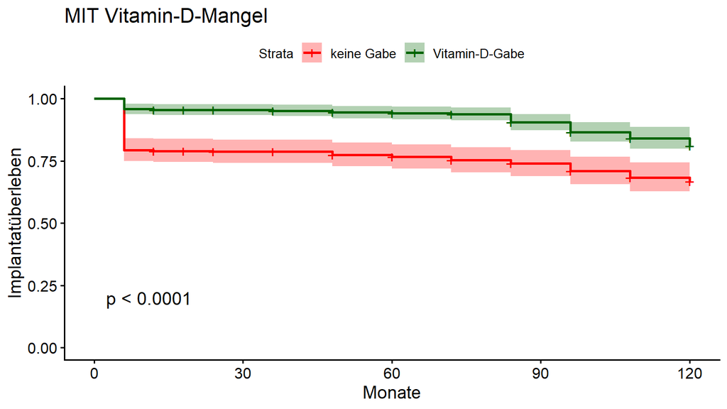

```r
rct_mangel <- rct |> filter(vit_d_mangel == "Mangel")
rct_kein   <- rct |> filter(vit_d_mangel == "kein Mangel")

ggsurvplot(
  survfit(Surv(months_passed, lost) ~ vit_d_gabe, data = rct_mangel),
  data = rct_mangel, pval = TRUE, conf.int = TRUE, palette = c("red", "darkgreen"),
  legend.labs = c("keine Gabe", "Vitamin-D-Gabe"),
  xlab = "Monate", ylab = "Implantatüberleben", title = "MIT Vitamin-D-Mangel")
```

**Code anzeigen**

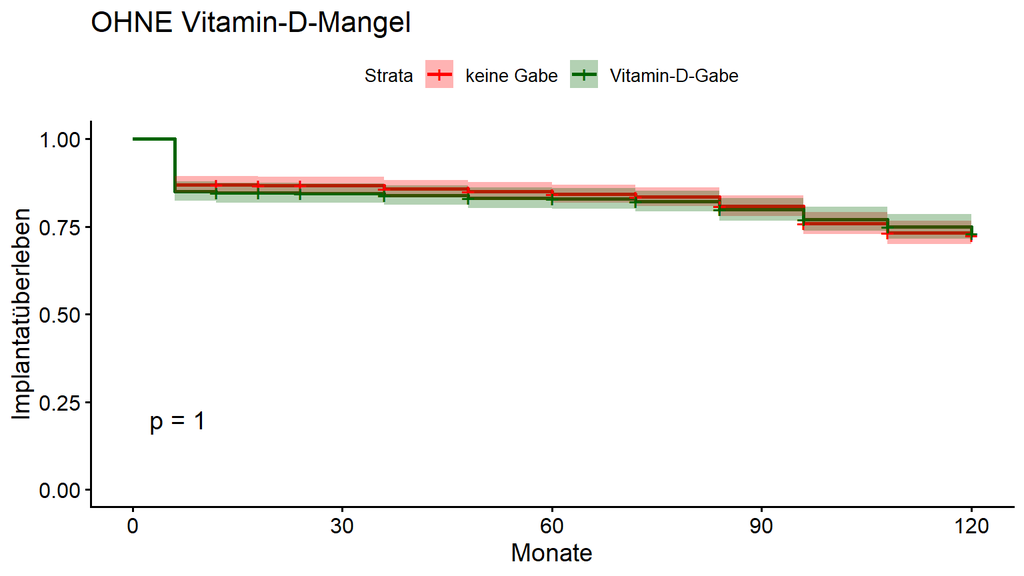

```r
ggsurvplot(
  survfit(Surv(months_passed, lost) ~ vit_d_gabe, data = rct_kein),
  data = rct_kein, pval = TRUE, conf.int = TRUE, palette = c("red", "darkgreen"),
  legend.labs = c("keine Gabe", "Vitamin-D-Gabe"),
  xlab = "Monate", ylab = "Implantatüberleben", title = "OHNE Vitamin-D-Mangel")
```

## Die Proportional-Hazards-Annahme

Das Cox-Modell nimmt an, dass ein HR über die **gesamte** Zeit **konstant** ist (*proportional hazards*, PH). Klinisch erwarten wir aber, dass die Gabe **nur beim Einheilen** hilft. Wir prüfen das dort, wo der Effekt sitzt – in der **Mangel-Gruppe**.

**Code anzeigen**

```r
cox_mangel <- coxph(Surv(months_passed, lost) ~ vit_d_gabe, data = rct_mangel)
ph_test <- cox.zph(cox_mangel)
ph_test
```

```
           chisq df       p
vit_d_gabe  18.9  1 1.4e-05
GLOBAL      18.9  1 1.4e-05
```

Der Test ist **hochsignifikant** – die PH-Annahme ist verletzt. Man muss den Zeitpunkt nicht vorher kennen: der Plot **zeigt** ihn.

**Code anzeigen**

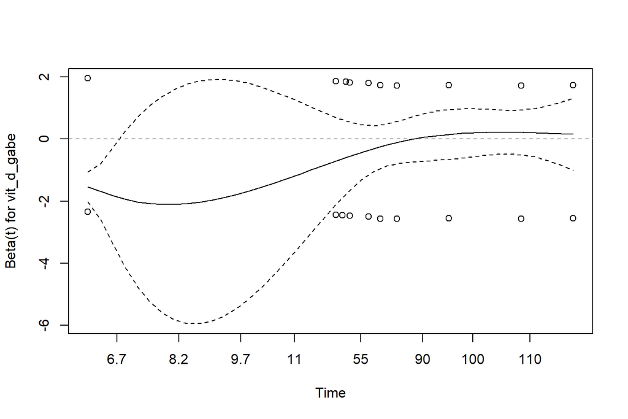

```r
plot(ph_test)
abline(h = 0, col = "grey60", lty = 2)
```

**So liest man den Plot:** x-Achse = Zeit, y-Achse = der *zu diesem Zeitpunkt* geschätzte Effekt (log-HR) der Gabe. Wäre PH erfüllt, verliefe die Linie **waagerecht**. Hier liegt sie **früh tief** (starker Schutz, HR ≪ 1) und **steigt gegen 0** – der Schutz verschwindet nach wenigen Monaten.

**Code anzeigen**

```r
rct_split <- survSplit(
  Surv(months_passed, lost) ~ ., data = rct_mangel, cut = 6, episode = "periode"
) |>
  mutate(periode = factor(periode, c(1, 2), c("früh (≤6 Mo)", "spät (>6 Mo)")))

b <- coef(coxph(Surv(tstart, months_passed, lost) ~ vit_d_gabe * periode, data = rct_split))
tibble::tibble(
  Periode = c("früh (≤6 Mo)", "spät (>6 Mo)"),
  HR_Gabe = c(exp(b["vit_d_gabeVitamin-D-Gabe"]),
              exp(b["vit_d_gabeVitamin-D-Gabe"] +
                  b["vit_d_gabeVitamin-D-Gabe:periodespät (>6 Mo)"]))
)
```

```
# A tibble: 2 × 2
  Periode      HR_Gabe
  <chr>          <dbl>
1 früh (≤6 Mo)   0.184
2 spät (>6 Mo)   0.920
```

Das ergibt **früh HR ≈ 0,2** (starker Schutz), **spät HR ≈ 0,9** (kein Effekt).

## Ergebnis von Teil A – kausale Interpretation

**Code anzeigen**

```r
cox_int |>
  tbl_regression(exponentiate = TRUE) |>
  bold_labels() |>
  bold_p()
```

| **Characteristic** | **HR** | **95% CI** | **p-value** |
| --- | --- | --- | --- |
| vit_d_gabe |  |  |  |
| keine Gabe | — | — |  |
| Vitamin-D-Gabe | 1.00 | 0.77, 1.29 | >0.9 |
| vit_d_mangel |  |  |  |
| kein Mangel | — | — |  |
| Mangel | 1.46 | 1.07, 2.01 | 0.019 |
| frailty(patient_id) |  |  | 0.008 |
| vit_d_gabe * vit_d_mangel |  |  |  |
| Vitamin-D-Gabe * Mangel | 0.37 | 0.23, 0.60 | <0.001 |

Abbreviations: CI = Confidence Interval, HR = Hazard Ratio

Weil die Gabe **randomisiert** war, ist eine **kausale** Lesart gerechtfertigt – **ohne** jede Confounder-Adjustierung:

- Bei Patienten **mit Mangel** senkt die Vitamin-D-Gabe die Verlustrate um rund **60 %** (HR ≈ 0,4), über einen **frühen** Schutz der Osseointegration.
- Bei Patienten **ohne Mangel** hat sie **keinen** Effekt.

# Teil B – Beobachtungsdaten (Routinedaten) und Confounding

Jetzt folgende Situation: Wir haben keine randomisierte Studie, sondern Routinedaten aus Praxen. Darin steht der gemessene Vitamin-D-Spiegel (ng/ml) zum Zeitpunkt der Implantation und das Implantatüberleben.

Die Frage lautet nun: Hängt ein Vitamin-D-Mangel (< 20 ng/ml) mit schlechterem Implantatüberleben zusammen?

**Code anzeigen**

```r
routine <- readRDS(here("Daten", "Beispieldaten_Routine.rds")) |>
  mutate(
    female       = factor(female,       c(0, 1), c("männlich", "weiblich")),
    smoke        = factor(smoke,        c(0, 1), c("Nichtraucher", "Raucher")),
    vit_d_mangel = factor(vit_d_mangel, c(0, 1), c("kein Mangel", "Mangel"))
  )
```

## Tabelle 1: die Gruppen sind *nicht* vergleichbar

Anders als im RCT gibt es hier keine Randomisierung. Wir vergleichen die Merkmale nach Mangel-Status:

**Code anzeigen**

```r
routine |>
  distinct(patient_id, .keep_all = TRUE) |>
  select(vit_d_mangel, alter, female, smoke) |>
  tbl_summary(
    by = vit_d_mangel,
    label = list(alter ~ "Alter (Jahre)", female ~ "Geschlecht", smoke ~ "Rauchen")
  ) |>
  modify_header(label ~ "**Charakteristik**") |>
  as_flex_table()
```

| Charakteristik | kein Mangel N = 5051 | Mangel N = 2951 |
| --- | --- | --- |
| Alter (Jahre) | 59 (52, 65) | 67 (60, 71) |
| Geschlecht |  |  |
| männlich | 255 (50%) | 159 (54%) |
| weiblich | 250 (50%) | 136 (46%) |
| Rauchen |  |  |
| Nichtraucher | 363 (72%) | 212 (72%) |
| Raucher | 142 (28%) | 83 (28%) |

1Median (Q1, Q3); n (%)

Patienten mit Mangel sind im Schnitt **deutlich älter**.

## Der naive (rohe) Effekt

**Code anzeigen**

```r
coxph(Surv(months_passed, lost) ~ vit_d_mangel, data = routine) |>
  summary()
```

```
Call:
coxph(formula = Surv(months_passed, lost) ~ vit_d_mangel, data = routine)

  n= 2105, number of events= 587

                      coef exp(coef) se(coef)     z Pr(>|z|)
vit_d_mangelMangel 0.57589   1.77871  0.08276 6.958 3.45e-12 ***
---
Signif. codes:  0 '***' 0.001 '**' 0.01 '*' 0.05 '.' 0.1 ' ' 1

                   exp(coef) exp(-coef) lower .95 upper .95
vit_d_mangelMangel     1.779     0.5622     1.512     2.092

Concordance= 0.582  (se = 0.011 )
Likelihood ratio test= 47.21  on 1 df,   p=6e-12
Wald test            = 48.42  on 1 df,   p=3e-12
Score (logrank) test = 49.77  on 1 df,   p=2e-12
```

Roh sieht es so aus, als erhöhe ein Mangel das Verlustrisiko um rund **80 %** (HR ≈ 1,8). Aber: Ist das der Effekt des **Mangels** – oder des **Alters**?

## Confounding sichtbar machen: der DAG

Ein Confounder ist eine **gemeinsame Ursache** von Exposition *und* Zielgröße. Zeichnen wir die vermuteten kausalen Zusammenhänge auf:

**Code anzeigen**

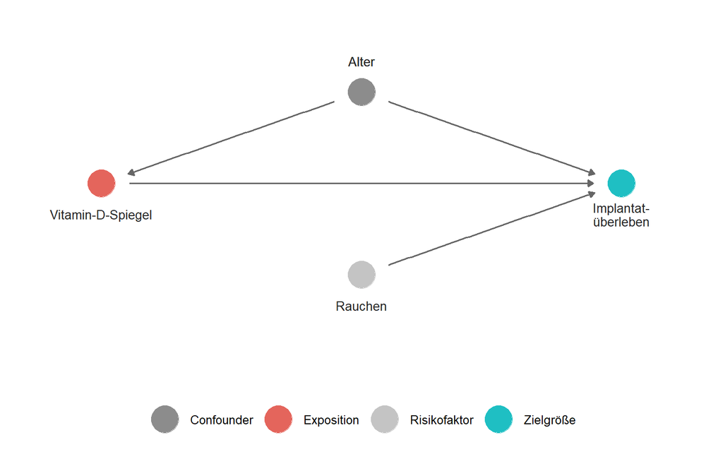

```r
# Knoten-Positionen fest vorgeben: Exposition links, Zielgröße rechts (eine Linie),
# Confounder oben, Risikofaktor unten.
dag <- dagify(
  Ueberleben ~ Spiegel + Alter + Rauchen,
  Spiegel ~ Alter,
  exposure = "Spiegel", outcome = "Ueberleben",
  coords = list(
    x = c(Spiegel = 0, Ueberleben = 2.4, Alter = 1.2, Rauchen = 1.2),
    y = c(Spiegel = 0, Ueberleben = 0,   Alter = 1,   Rauchen = -1)
  )
)

dag_plot <- tidy_dagitty(dag) |>
  mutate(
    rolle = case_when(
      name == "Spiegel"    ~ "Exposition",
      name == "Ueberleben" ~ "Zielgröße",
      name == "Alter"      ~ "Confounder",
      TRUE                 ~ "Risikofaktor"
    ),
    lab = recode(name,
                 Spiegel = "Vitamin-D-Spiegel", Ueberleben = "Implantat-\nüberleben",
                 Alter = "Alter", Rauchen = "Rauchen"),
    ny = if_else(name == "Alter", 0.34, -0.34)   # Label ober- bzw. unterhalb des Knotens
  )

ggplot(dag_plot, aes(x = x, y = y, xend = xend, yend = yend)) +
  geom_dag_edges(edge_color = "grey40") +
  geom_dag_point(aes(color = rolle), size = 10) +
  geom_text(aes(y = y + ny, label = lab), size = 3.5, lineheight = 0.9, color = "grey15") +
  scale_color_manual(
    values = c(Exposition = "#E4655C", "Zielgröße" = "#1FBFC3",
               Confounder = "#8C8C8C", Risikofaktor = "#C4C4C4"),
    name = NULL
  ) +
  scale_x_continuous(expand = expansion(c(0.18, 0.18))) +
  scale_y_continuous(expand = expansion(c(0.30, 0.22))) +
  theme_dag() +
  theme(legend.position = "bottom")
```

- **Alter** zeigt auf **beides** (niedrigerer Spiegel *und* schlechteres Überleben) → **Confounder** → wir müssen dafür adjustieren.
- **Rauchen** zeigt nur auf das Überleben, nicht auf den Spiegel → kein Confounder.

Der `dagitty`-Algorithmus bestätigt das notwendige Adjustierungsset:

**Code anzeigen**

```r
adjustmentSets(dag)
```

```
{ Alter }
```

## Der adjustierte Effekt – und was sich ändert

**Code anzeigen**

```r
hr_row <- function(formel, name) {
  m <- coxph(as.formula(formel), data = routine)
  ci <- summary(m)$conf.int["vit_d_mangelMangel", ]
  tibble::tibble(Modell = name, HR = round(ci["exp(coef)"], 2),
                 CI_unten = round(ci["lower .95"], 2), CI_oben = round(ci["upper .95"], 2))
}

dplyr::bind_rows(
  hr_row("Surv(months_passed, lost) ~ vit_d_mangel", "roh (unadjustiert)"),
  hr_row("Surv(months_passed, lost) ~ vit_d_mangel + smoke", "+ Rauchen (kein Confounder)"),
  hr_row("Surv(months_passed, lost) ~ vit_d_mangel + alter", "+ Alter (Confounder)"),
  hr_row("Surv(months_passed, lost) ~ vit_d_mangel + alter + female", "+ Alter + Geschlecht")
)
```

```
# A tibble: 4 × 4
  Modell                         HR CI_unten CI_oben
  <chr>                       <dbl>    <dbl>   <dbl>
1 roh (unadjustiert)           1.78     1.51    2.09
2 + Rauchen (kein Confounder)  1.8      1.53    2.12
3 + Alter (Confounder)         1.41     1.19    1.67
4 + Alter + Geschlecht         1.41     1.18    1.67
```

Bewegung der HR:

- **+ Rauchen** ändert den Mangel-Effekt **kaum** (≈ 1,8 → 1,8) – Rauchen ist kein Confounder, auch wenn es das Überleben stark beeinflusst.
- **+ Alter** senkt ihn deutlich (≈ 1,8 → 1,4) – Alter war ein Teil des scheinbaren Mangel-Effekts. Ein Teil des rohen „Mangel-Schadens” war in Wahrheit **Alters-Schaden**.

## Das adjustierte Modell (mit Clustering)

**Code anzeigen**

```r
cox_b <- coxph(
  Surv(months_passed, lost) ~ vit_d_mangel + alter + female + frailty(patient_id),
  data = routine
)
cox_b |>
  tbl_regression(exponentiate = TRUE) |>
  bold_labels() |>
  bold_p()
```

| **Characteristic** | **HR** | **95% CI** | **p-value** |
| --- | --- | --- | --- |
| vit_d_mangel |  |  |  |
| kein Mangel | — | — |  |
| Mangel | 1.51 | 1.20, 1.90 | <0.001 |
| alter | 1.04 | 1.03, 1.05 | <0.001 |
| female |  |  |  |
| männlich | — | — |  |
| weiblich | 0.90 | 0.72, 1.11 | 0.3 |
| frailty(patient_id) |  |  | <0.001 |

Abbreviations: CI = Confidence Interval, HR = Hazard Ratio

## Table-2-Fallacy

In dieser Tabelle steht auch **Alter** mit einer HR. **Nicht** kausal interpretieren! Alter wurde nur als Confounder ins Modell genommen. Um den Alters-Effekt sauber zu schätzen bräuchte man dessen eigene Confounder. Wer alle Zeilen einer Regressionstabelle gleichberechtigt kausal liest, begeht die **Table-2-Fallacy**. Sauber interpretierbar ist hier nur die **eine** Zielexposition: der Vitamin-D-Mangel.

## Was die Adjustierung leistet

Die Adjustierung für Alter macht die Vergleichsgruppen (Mangel vs. kein Mangel) hinsichtlich des Alters vergleichbar – sie baut von Hand nach, was die Randomisierung im RCT automatisch für alle Merkmale erledigt (auch die Unbeobachteten). Bei Beobachtungsstudien müssten wir alle relevanten Confounder kennen und auch erheben, um den Effekt zu entzerren.

## Fazit: RCT vs. Routinedaten

|  | Teil A – RCT | Teil B – Routinedaten |
| --- | --- | --- |
| Exposition zugeteilt durch | Randomisierung | Beobachtung (nicht zugeteilt) |
| Confounding | **keins** (per Design) | **problematisch** (z. B. Alter) |
| Confounder-Adjustierung | nicht nötig | **notwendig** (Alter), aber gezielt |
| Rohschätzer | bereits unverzerrt | **verzerrt** |
| Tabelle 1 | zeigt Balance | zeigt **Un**balance (Motivation!) |

Beide Male ist die Statistik (KM, Cox, Frailty) dieselbe – der Unterschied liegt im Design. Der RCT ist der Goldstandard, weil er Confounding durch Randomisierung ausschaltet. In Beobachtungsdaten kann man sich dem mit **DAG-geleiteter** Confounder-Auswahl und gezielter Adjustierung annähern – aber der berühmte Satz bleibt wahr: *„Korrelation ist nicht gleich Kausalität”* – es sei denn, man kontrolliert die richtigen Confounder (und nur die).